# Report

rdeganay

December 23rd, 2016

## Synopsis

This document is the report summarizing the end project of the Coursera Course Statistical Inference by John Hopkins University.

## Part 1 : Simulation Exercice

In this project we will investigate the exponential distribution in R and compare it with the Central Limit Theorem. Setting lambda to 0.2, here is a quick overview of its density:

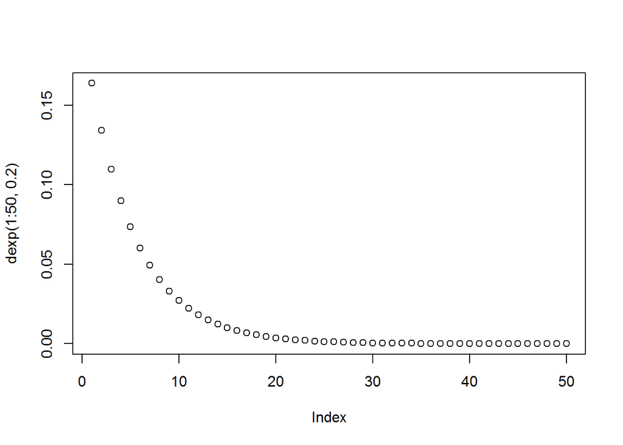

```r
plot(dexp(1:50, .2))
```

The mean of exponential distribution is 1/lambda (i.e. 5 in our case) and the standard deviation is also 1/lambda (again 5 in our case).

### Sample Mean and Variance

$$Y= \frac{ \sum_{i=1}^{40}X_i}{40}$$
According to the Central Limit Theorem, $Y$’s distribution is approximately normal, with a mean of 5 and of variance of 0.625.

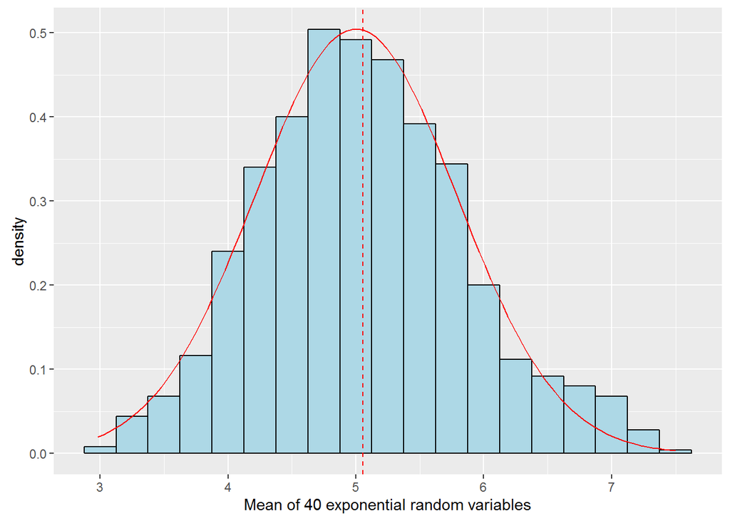

```r
set.seed(1337)
y = NULL

for (i in 1:1000) y = c(y, mean(rexp(40, .2)))


g <- ggplot(data.frame(y = y), aes(x=y)) +
  geom_histogram(aes(y=..density..), binwidth = .25, colour = 'black', fill = "lightblue") +
  xlab("Mean of 40 exponential random variables") +
  geom_vline(aes(xintercept=mean(y)), color = 'red', linetype="dashed") +
  stat_function(fun = dnorm, args = list(mean = 5, sd = 0.625^0.5), colour = "red")


print(g)
```

```r
x <- cbind(c(5, 0.625), c(mean(y), var(y)))
rownames(x) <- c("Mean", "Variance")
colnames(x) <- c("Theoretical", "Observed")
x
```

```
##          Theoretical  Observed
## Mean           5.000 5.0559953
## Variance       0.625 0.6543703
```

### Approximation of a normal distribution

In the previous plot, we drew the expected normal distribution on top of the density histogram. It clearly indicates that the distribution is indeed normal, as the CLT indicates.

## Part 2: Basic Inferential Data Analysis

We are now studying the ToothGrowth dataset from the R datasets package.

### Exploratory analysis

Let us take a quick look on the data set :

```r
head(ToothGrowth)
```

```
##    len supp dose
## 1  4.2   VC  0.5
## 2 11.5   VC  0.5
## 3  7.3   VC  0.5
## 4  5.8   VC  0.5
## 5  6.4   VC  0.5
## 6 10.0   VC  0.5
```

```r
summary(ToothGrowth)
```

```
##       len        supp         dose
##  Min.   : 4.20   OJ:30   Min.   :0.500
##  1st Qu.:13.07   VC:30   1st Qu.:0.500
##  Median :19.25           Median :1.000
##  Mean   :18.81           Mean   :1.167
##  3rd Qu.:25.27           3rd Qu.:2.000
##  Max.   :33.90           Max.   :2.000
```

It contains the length of odontoblasts (teeth) in each of 10 guinea pigs at each of three dose levels of Vitamin C (0.5, 1, and 2 mg) with each of two delivery methods (orange juice or ascorbic acid).

The Format is a data frame with 60 observations on 3 variables.

[,1] len numeric Tooth length  
[,2] supp factor Supplement type (VC or OJ).  
[,3] dose numeric Dose in milligrams.

Based on the description of the data it seems natural to observe the relationship between tooth length and Vitamin C dose, and to split the graphs based on the delivery method.

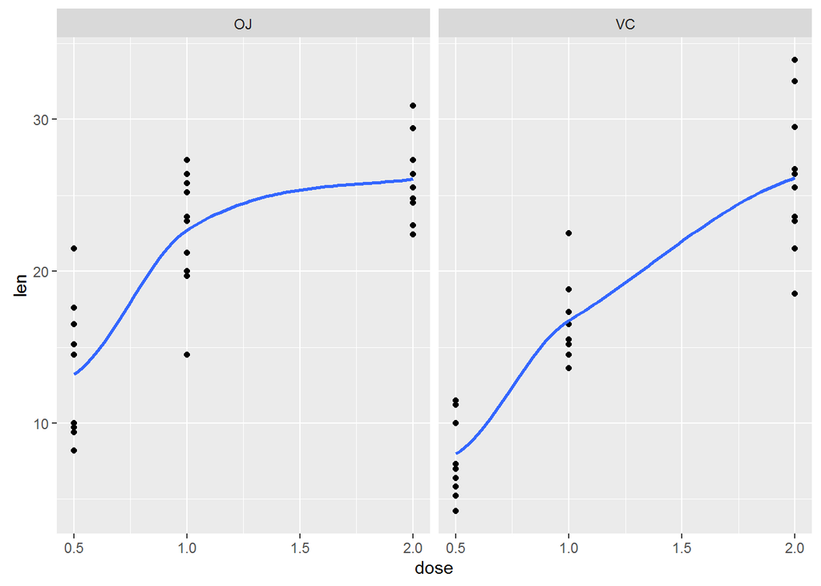

```r
g21 <- ggplot(ToothGrowth, aes(x=dose, y= len)) + facet_grid(.~supp) +
  geom_point() +  geom_smooth(se = FALSE)

print(g21)
```

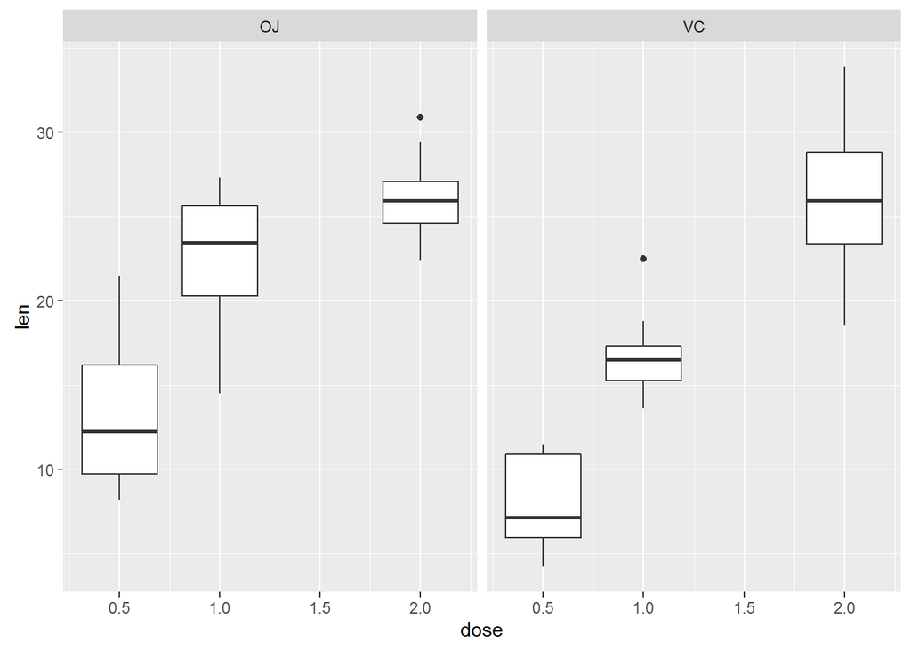

```r
g22 <- ggplot(ToothGrowth, aes(x=dose, y= len)) +
  geom_boxplot(aes(group=dose)) + facet_grid(.~supp)

print(g22)
```

### Basic summary

Based on these assumptions, the following briefly sums up the data: we calculate the mean tooth length according to the dose and the delivery method.

```r
ToothGrowth %>% select(dose, len) %>% group_by(dose) %>% summarise_each(funs(mean))
```

```
## # A tibble: 3 × 2
##    dose    len
##   <dbl>  <dbl>
## 1   0.5 10.605
## 2   1.0 19.735
## 3   2.0 26.100
```

```r
ToothGrowth %>% select(supp, len) %>% group_by(supp) %>% summarise_each(funs(mean))
```

```
## # A tibble: 2 × 2
##     supp      len
##   <fctr>    <dbl>
## 1     OJ 20.66333
## 2     VC 16.96333
```

This exploratory analysis and basic summary tends to indicate that:

- Vitamin C increases tooth length
- Orange juice is the most effective delivery method, especially associated with a dose of 0.5 and 1.0 mg.

### Normality test

We suppose tooth length follows a normal distribution, so that we can use Student t test in the following.

A quick look at the quantile-quantile plots (split according to the dose and the delivery method) tends to indicate that the hypothesys of normality is reasonnable.

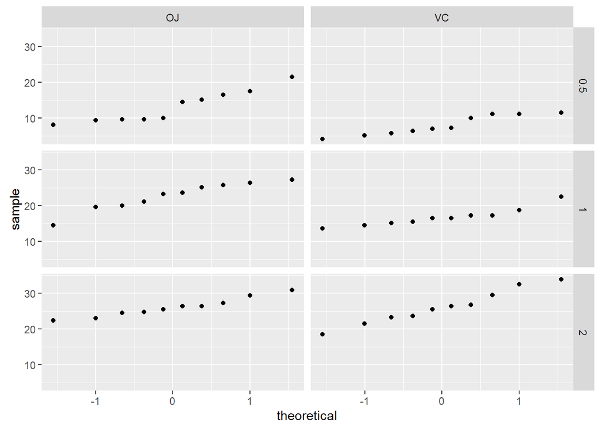

```r
g <- ggplot(ToothGrowth, aes(sample=len)) + stat_qq()
g + facet_grid(dose ~ supp)
```

To confirm this intuition we perform a Shapiro-Wilk Normality Test on each subset. The following shows the obtained p-values.

```r
shapiro <- c(shapiro.test(subset(ToothGrowth, dose == 0.5 & supp == "OJ")$len)[["p.value"]],
             shapiro.test(subset(ToothGrowth, dose == 1.0 & supp == "OJ")$len)[["p.value"]],
             shapiro.test(subset(ToothGrowth, dose == 2.0 & supp == "OJ")$len)[["p.value"]],
             shapiro.test(subset(ToothGrowth, dose == 0.5 & supp == "VC")$len)[["p.value"]],
             shapiro.test(subset(ToothGrowth, dose == 1.0 & supp == "VC")$len)[["p.value"]],
             shapiro.test(subset(ToothGrowth, dose == 2.0 & supp == "VC")$len)[["p.value"]])

pvalue <- cbind(shapiro[1:3], shapiro[4:6])
colnames(pvalue) <- c("OJ", "VC")
rownames(pvalue) <- c("0.5", "1.0", "1.5")

pvalue
```

```
##            OJ        VC
## 0.5 0.1820408 0.1695627
## 1.0 0.4152983 0.2697855
## 1.5 0.8147908 0.9194497
```

In no cases can we reject a normal distribution, so we assume that tooth length does follow a normal distribution.

### Influence of the dose of vitamin C on Tooth Growth

We want to test the following hypothesis : The dose of Vitamin C helps Guinea Pigs teeth grow.

**$H_0$ therefore states that the mean tooth length is independant from the dose.**

We will use Welch t test on two subsets of the data.

```r
tg_small <- subset(ToothGrowth, dose %in% c(0.5, 1.0))
tg_big <- subset(ToothGrowth, dose %in% c(1.0, 2.0))

t.test(len ~ dose, data = tg_small, var.equal = FALSE)
```

```
##
##  Welch Two Sample t-test
##
## data:  len by dose
## t = -6.4766, df = 37.986, p-value = 1.268e-07
## alternative hypothesis: true difference in means is not equal to 0
## 95 percent confidence interval:
##  -11.983781  -6.276219
## sample estimates:
## mean in group 0.5   mean in group 1
##            10.605            19.735
```

```r
t.test(len ~ dose, data = tg_big, var.equal = FALSE)
```

```
##
##  Welch Two Sample t-test
##
## data:  len by dose
## t = -4.9005, df = 37.101, p-value = 1.906e-05
## alternative hypothesis: true difference in means is not equal to 0
## 95 percent confidence interval:
##  -8.996481 -3.733519
## sample estimates:
## mean in group 1 mean in group 2
##          19.735          26.100
```

We can reject the null hypothesis in both cases and conclude that vitamin C has an impact on tooth length. The bigger the dose, the longer the teeth.

### Influence of the supplement type on Tooth Growth

We suppose the injection method has an impact on tooth growth.

**$H_0$ therefore states that the mean tooth length is independant from the injection method.**

We use again Welch t test, this time on the whole data.

```r
t.test(len ~ supp, data = ToothGrowth, var.equal = FALSE)
```

```
##
##  Welch Two Sample t-test
##
## data:  len by supp
## t = 1.9153, df = 55.309, p-value = 0.06063
## alternative hypothesis: true difference in means is not equal to 0
## 95 percent confidence interval:
##  -0.1710156  7.5710156
## sample estimates:
## mean in group OJ mean in group VC
##         20.66333         16.96333
```

With a p value of around 6% we are a little short to reject the null hypothesis.

To further investigate and based on the previous exploration and summary, let us perform the same analysis only on guinea pigs that have received a dose of 0.5 or 1.0 mg vitamin C.

```r
t.test(len ~ supp, data = tg_small, var.equal = FALSE)
```

```
##
##  Welch Two Sample t-test
##
## data:  len by supp
## t = 3.0503, df = 36.553, p-value = 0.004239
## alternative hypothesis: true difference in means is not equal to 0
## 95 percent confidence interval:
##  1.875234 9.304766
## sample estimates:
## mean in group OJ mean in group VC
##           17.965           12.375
```

We can here reject the null hypothesis and conclude that for a dose smaller than 1.0 mg, the orange juice is more efficient than the ascorbic acid.

### Assumptions and Conclusions

Under the assumption that guinea pigs tooth length follows a normal distribution, we reached the following conclusions :

- Vitamin C helps guinea pigs teeth to grow
- for a dose equal or smaller than 1.0 mg, orange juice is a more efficient injection method than ascorbic acid.